# Analyze prosperity from the perspectives of labor and education

```python
# the second sector is education

education_columns = [
    'teriary_education_participation_rate',
    'education_spend_as_percent_of_GDP',
    'education_spend_as_percent_of_total_gov_expenses',
    'median_teriary_loan_as_perc_of_med_inc_AHC',
    'median_teriary_loan_balance_as_perc_of_med_inc_AHC',
    'university_affordability_ratio_to_mean_salary',
    'polytechnics_affordability_ratio_to_mean_salary',
    'wananga_affordability_ratio_to_mean_salary',
    'bachelors_earning_premium_hourly',
    'dips_cert_earning_premium_hourly',
    'school_earning_premium_hourly',
    'bachelors_earning_premium_weekly',
    'dips_cert_earning_premium_weekly',
    'school_earning_premium_weekly',
]
education = data[education_columns]
```

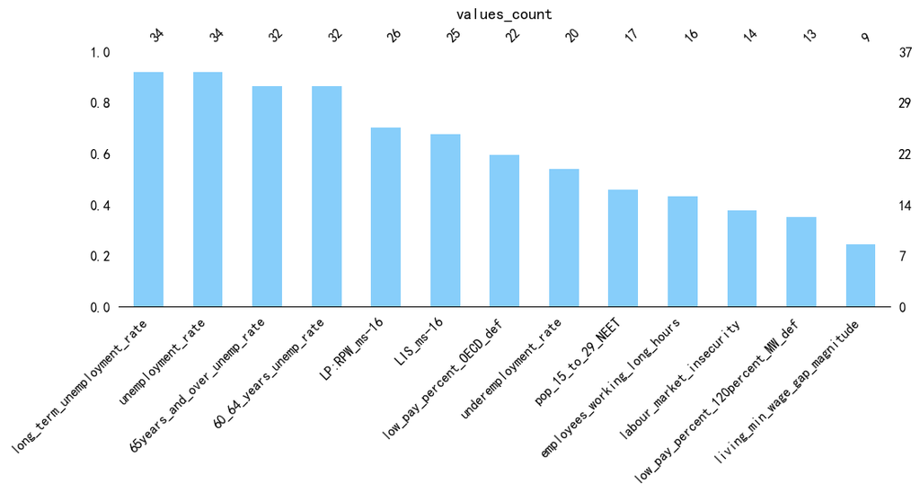

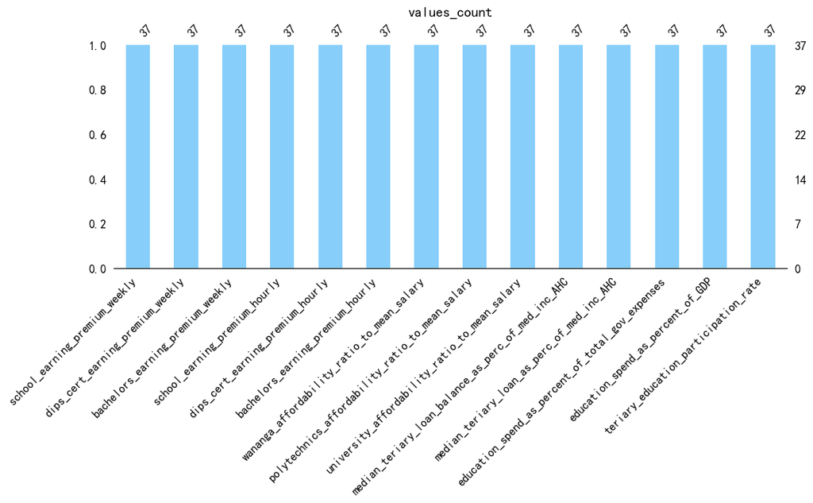

```python
# using missingno to check out missing values situation

import missingno as msno
def plot_missing_values(df):
    plt.rcParams['font.family'] = 'SimHei'
    fig, ax = plt.subplots(figsize=(12, 4))
    msno.bar(df, sort='descending', ax=ax, filter='top', color='lightskyblue', fontsize=12)
    ax.spines['bottom'].set_visible(True)
    plt.title('values_count', fontsize=14)
    plt.show()
plot_missing_values(labour)
plot_missing_values(education)
```

```python
# As can be seen from the histogram above, many columns of labor are missing, while education has values.
# But it is not missing, which does not mean that the value is normal. Next, check the value.
```

```python
labour.info()
labour
```

```
<class 'pandas.core.frame.DataFrame'>
Int64Index: 37 entries, 1982 to 2018
Data columns (total 13 columns):
 #   Column                             Non-Null Count  Dtype
---  ------                             --------------  -----
 0   unemployment_rate                  34 non-null     object
 1   60_64_years_unemp_rate             32 non-null     float64
 2   65years_and_over_unemp_rate        32 non-null     object
 3   underemployment_rate               20 non-null     object
 4   employees_working_long_hours       16 non-null     object
 5   labour_market_insecurity           14 non-null     object
 6   long_term_unemployment_rate        34 non-null     object
 7   pop_15_to_29_NEET                  17 non-null     object
 8   low_pay_percent_OECD_def           22 non-null     object
 9   low_pay_percent_120percent_MW_def  13 non-null     object
 10  living_min_wage_gap_magnitude      9 non-null      object
 11  LIS_ms-16                          25 non-null     object
 12  LP:RPW_ms-16                       26 non-null     object
dtypes: float64(1), object(12)
memory usage: 4.0+ KB
```

| year | unemployment_rate | 60_64_years_unemp_rate | 65years_and_over_unemp_rate | underemployment_rate | employees_working_long_hours | labour_market_insecurity | long_term_unemployment_rate | pop_15_to_29_NEET | low_pay_percent_OECD_def | low_pay_percent_120percent_MW_def | living_min_wage_gap_magnitude | LIS_ms-16 | LP:RPW_ms-16 |
| --- | --- | --- | --- | --- | --- | --- | --- | --- | --- | --- | --- | --- | --- |
| 1982 | NAN | NaN | NaN | NAN | NaN | NAN | NaN | NaN | NaN | NaN | NaN | NaN | NaN |
| 1983 | NaN | NaN | NaN | NaN | NAN | NaN | NaN | NaN | NaN | NaN | NaN | NaN | NaN |
| 1984 | NaN | NaN | NAN | NaN | NaN | NaN | NAN | NaN | NaN | NaN | NaN | NaN | NaN |
| 1985 | NAN | NaN | NAN | NaN | NaN | NaN | NAN | NaN | NaN | NaN | NaN | NAN | NaN |
| 1986 | 4.2 | 1.3 | 2 | NaN | NaN | NaN | 7.93319426 | NaN | NaN | NaN | NaN | NaN | NaN |
| 1987 | 4.2 | 1.3 | 1.7 | NaN | NaN | NaN | 10.56751469 | NaN | NaN | NaN | NaN | NAN | NaN |
| 1988 | 5.8 | 2.3 | 2.3 | NAN | NaN | NaN | 13.48464633 | NaN | NaN | NaN | NaN | NAN | NAN |
| 1989 | 7.3 | 2.3 | 3.4 | NaN | NaN | NaN | 17.44897948 | NAN | NaN | NAN | NaN | NaN | NAN |
| 1990 | 8 | 3.3 | 2.1 | NaN | NaN | NaN | 22.06366623 | NaN | NaN | NaN | NaN | NaN | NAN |
| 1991 | 10.6 | 2.8 | 2.5 | NaN | NaN | NAN | 24.32269694 | NaN | NaN | NAN | NaN | NaN | NaN |
| 1992 | 10.7 | 2.7 | 1.7 | NaN | NaN | NaN | 32.37237262 | NAN | NaN | NaN | NAN | NaN | NaN |
| 1993 | 9.8 | 2.5 | 1.7 | NaN | NaN | NaN | 33.7628865 | NaN | NAN | NAN | NaN | NaN | NaN |
| 1994 | 8.4 | 3.3 | 2.3 | NaN | NaN | NAN | 32.93502612 | NaN | NaN | NaN | NaN | NaN | NAN |
| 1995 | 6.5 | 2.7 | 1.5 | NaN | NaN | NaN | 25.84053796 | NaN | NaN | NaN | NAN | NaN | NaN |
| 1996 | 6.3 | 2.9 | 1.4 | NaN | NaN | NaN | 21.16650992 | NaN | NaN | NaN | NAN | 0.573814339 | 0.982628357 |
| 1997 | 6.8 | 3.3 | 1 | NAN | NAN | NaN | 19.72672923 | NaN | 13.27024441 | NaN | NAN | 0.577402517 | 0.974400011 |
| 1998 | 7.7 | 3.4 | 1.2 | NAN | NaN | NaN | 19.51951938 | NaN | 13.12055621 | NAN | NaN | 0.57695473 | 0.975691793 |
| 1999 | 7 | 5.4 | 1.8 | NaN | NAN | NaN | 21.14427859 | NaN | 12.28404701 | NaN | NAN | 0.58646245 | 0.961097219 |
| 2000 | 6.1 | 4.8 | 1.7 | NAN | NaN | NaN | 19.86564299 | NaN | 11.73855902 | NaN | NaN | 0.566411227 | 1 |
| 2001 | 5.5 | 3.4 | 1.3 | NaN | NaN | NAN | 17.34475386 | NaN | 12.22912863 | NaN | NaN | 0.552677842 | 1.027041175 |
| 2002 | 5.3 | 4.0 | 1.7 | NaN | NAN | NaN | 14.76293119 | NaN | 13.62982548 | NaN | NaN | 0.547495509 | 1.036569721 |
| 2003 | 4.8 | 3.7 | 1.2 | NAN | NaN | NaN | 13.60946763 | NaN | 13.2223601 | NAN | NaN | 0.554726914 | 1.023312736 |
| 2004 | 4 | 2.5 | NaN | 3.3 | NaN | NaN | 11.65048555 | 10.8 | 13.16200699 | NAN | NaN | 0.558436539 | 1.016300545 |
| 2005 | 3.8 | 2.1 | 1.5 | 2.8 | 15.65180621 | NaN | 9.84308144 | 11.1 | 12.43929872 | NaN | NaN | 0.560911148 | 1.014533128 |
| 2006 | 3.9 | 1.9 | 1.7 | 2.8 | 14.93161991 | NaN | 7.649513333 | 10.7 | 14.61223605 | 17.9 | NaN | 0.575006286 | 0.989086531 |
| 2007 | 3.6 | 1.2 | NaN | 3.1 | 14.74332887 | 3.250449181 | 5.967976829 | 10.9 | 13.44092008 | NaN | NaN | 0.576097368 | 0.987016986 |
| 2008 | 4 | 2.1 | 1.1 | 3.2 | 14.15375627 | 3.389422894 | 4.326328892 | 11.1 | 12.53418077 | NAN | NaN | 0.566552623 | 1.009076817 |
| 2009 | 5.8 | 2.9 | 1.4 | 4.3 | 13.43555398 | 5.232753754 | 6.413301781 | 14.1 | 12.87324359 | 24 | NaN | 0.576229725 | 0.995758226 |
| 2010 | 6.1 | 3.0 | 1.5 | 3.9 | 13.76879701 | 5.601137161 | 8.879184954 | 13.4 | 12.72185373 | NAN | NaN | 0.556224675 | 1.03122756 |
| 2011 | 6 | 2.9 | 1.7 | 4 | 13.28523676 | 5.591565609 | 8.914450139 | 13.2 | 13.69347462 | NaN | NaN | 0.556565361 | 1.030702749 |
| 2012 | 6.4 | 3.9 | 1.6 | 4.2 | 13.26356628 | 5.885300636 | 13.29677878 | 13.5 | 13.55530034 | 23.9 | NaN | 0.553735337 | 1.037463792 |
| 2013 | 5.8 | 3.6 | 1.6 | 4.1 | 14.08515265 | 5.332859516 | 12.17257318 | 11.9 | 14.08030591 | NaN | 1.793478261 | 0.563012705 | 1.021230837 |
| 2014 | 5.4 | 2.9 | 1.6 | 4.1 | 14.03208924 | 4.76441288 | 13.63636376 | 11.4 | 13.86467017 | NaN | 2.046542553 | 0.542572373 | 1.059572811 |
| 2015 | 5.4 | 3.1 | 1.5 | 3.9 | 13.61419301 | 4.68318224 | 13.20604627 | 11.3 | 13.89062945 | 24.9 | 2.451948052 | 0.556715416 | 1.031727924 |
| 2016 | 5.1 | 3.0 | 1.2 | 4.3 | 15.0208549 | 4.4 | 14.14554371 | 12 | 11.18821004 | NaN | 2.233585859 | 0.556034802 | 1.032523909 |
| 2017 | 4.7 | 3.1 | 1.2 | 4.4 | NaN | NaN | 15.64339767 | 11.8 | 12.09159648 | NAN | NaN | NAN | NaN |
| 2018 | NaN | NaN | NaN | NaN | NaN | NaN | NaN | NAN | NaN | NaN | NaN | NaN | NAN |

```python
education.info()
education
```

```
<class 'pandas.core.frame.DataFrame'>
Int64Index: 37 entries, 1982 to 2018
Data columns (total 14 columns):
 #   Column                                              Non-Null Count  Dtype
---  ------                                              --------------  -----
 0   teriary_education_participation_rate                37 non-null     object
 1   education_spend_as_percent_of_GDP                   37 non-null     object
 2   education_spend_as_percent_of_total_gov_expenses    37 non-null     object
 3   median_teriary_loan_as_perc_of_med_inc_AHC          37 non-null     object
 4   median_teriary_loan_balance_as_perc_of_med_inc_AHC  37 non-null     object
 5   university_affordability_ratio_to_mean_salary       37 non-null     object
 6   polytechnics_affordability_ratio_to_mean_salary     37 non-null     object
 7   wananga_affordability_ratio_to_mean_salary          37 non-null     object
 8   bachelors_earning_premium_hourly                    37 non-null     object
 9   dips_cert_earning_premium_hourly                    37 non-null     object
 10  school_earning_premium_hourly                       37 non-null     object
 11  bachelors_earning_premium_weekly                    37 non-null     object
 12  dips_cert_earning_premium_weekly                    37 non-null     object
 13  school_earning_premium_weekly                       37 non-null     object
dtypes: object(14)
memory usage: 4.3+ KB
```

| year | teriary_education_participation_rate | education_spend_as_percent_of_GDP | education_spend_as_percent_of_total_gov_expenses | median_teriary_loan_as_perc_of_med_inc_AHC | median_teriary_loan_balance_as_perc_of_med_inc_AHC | university_affordability_ratio_to_mean_salary | polytechnics_affordability_ratio_to_mean_salary | wananga_affordability_ratio_to_mean_salary | bachelors_earning_premium_hourly | dips_cert_earning_premium_hourly | school_earning_premium_hourly | bachelors_earning_premium_weekly | dips_cert_earning_premium_weekly | school_earning_premium_weekly |
| --- | --- | --- | --- | --- | --- | --- | --- | --- | --- | --- | --- | --- | --- | --- |
| 1982 | nan\F\U | nan\P | nan\F | nan\X | nan\Q | nan\Y | nan\F | nan\K | nan\L | nan\Q | nan\S | nan\O | nan\N | nan\U |
| 1983 | nan\P\S | nan\B | nan\H | nan\Z | nan\B | nan\T | nan\A | nan\H | nan\P | nan\J | nan\F | nan\G | nan\X | nan\B |
| 1984 | nan\U\U | nan\F | nan\E | nan\J | nan\C | nan\K | nan\I | nan\J | nan\K | nan\W | nan\V | nan\N | nan\C | nan\K |
| 1985 | nan\F\E | nan\K | nan\O | nan\M | nan\C | nan\Y | nan\B | nan\S | nan\N | nan\J | nan\I | nan\H | nan\O | nan\Y |
| 1986 | nan\T\R | nan\T | nan\V | nan\V | nan\M | nan\I | nan\Y | nan\S | nan\G | nan\A | nan\A | nan\B | nan\N | nan\Q |
| 1987 | nan\J\N | nan\H | nan\W | nan\A | nan\W | nan\O | nan\T | nan\E | nan\L | nan\N | nan\Q | nan\M | nan\W | nan\R |
| 1988 | nan\B\G | nan\P | nan\D | nan\I | nan\U | nan\Y | nan\J | nan\X | nan\Z | nan\Z | nan\M | nan\K | nan\P | nan\N |
| 1989 | nan\S\F | nan\A | nan\K | nan\F | nan\R | nan\H | nan\F | nan\A | nan\B | nan\U | nan\Z | nan\T | nan\U | nan\I |
| 1990 | nan\T\Z | nan\A | nan\P | nan\H | nan\P | nan\W | nan\I | nan\Z | nan\W | nan\L | nan\G | nan\P | nan\P | nan\X |
| 1991 | nan\G\H | nan\O | nan\Q | nan\M | nan\V | nan\X | nan\W | nan\F | nan\M | nan\B | nan\Q | nan\K | nan\B | nan\I |
| 1992 | nan\U\X | nan\A | nan\U | nan\D | nan\V | nan\T | nan\O | nan\N | nan\I | nan\V | nan\X | nan\F | nan\Q | nan\X |
| 1993 | nan\K\M | nan\K | nan\U | nan\O | nan\S | nan\Z | nan\M | nan\G | nan\R | nan\P | nan\V | nan\P | nan\K | nan\D |
| 1994 | 7.3\N\P | nan\K | nan\I | nan\Z | nan\X | nan\R | nan\F | nan\P | nan\B | nan\T | nan\H | nan\O | nan\D | nan\N |
| 1995 | 8.1\R\T | nan\U | nan\F | nan\J | nan\R | nan\H | nan\B | nan\W | nan\M | nan\Q | nan\C | nan\B | nan\U | nan\X |
| 1996 | 8.200000000000001\B\W | nan\N | nan\W | nan\I | nan\D | nan\R | nan\P | nan\K | nan\Z | nan\N | nan\M | nan\A | nan\U | nan\S |
| 1997 | 8.1\E\G | 4.8\H | 15.4\M | nan\C | nan\U | nan\I | nan\O | nan\C | nan\J | nan\U | nan\T | nan\U | nan\B | nan\J |
| 1998 | 8.3\W\M | 4.9\K | 15.7\T | nan\I | nan\I | nan\I | nan\J | nan\V | nan\B | nan\S | nan\J | nan\P | nan\A | nan\J |
| 1999 | 9.4\Q\C | 5.0\Z | 15.7\J | nan\Q | nan\P | nan\T | nan\N | nan\X | nan\E | nan\Z | nan\Z | nan\U | nan\I | nan\W |
| 2000 | 10.1\U\W | 5.0\A | 16.4\V | 25.68303400840658\G | 39.93121895299962\I | 5.559656080630483\L | 5.368577686550889\R | 3.859013985972417\S | nan\R | nan\A | nan\D | nan\V | nan\G | nan\W |
| 2001 | 11.0\Y\W | 5.1\D | 16.8\H | 25.97396449704142\B | 39.08165680473373\E | 5.551530319919428\O | 4.960433429642005\E | 1.794410239487352\X | nan\C | nan\P | nan\R | nan\V | nan\C | nan\V |
| 2002 | 11.9\E\S | 5.0\Q | 17.3\O | 24.71911832236339\T | 37.98561151079137\A | 5.235648764126072\S | 4.400569236548513\J | 0.8853161140067168\L | nan\O | nan\N | nan\Z | nan\X | nan\W | nan\K |
| 2003 | 12.5\A\W | 5.2\A | 17.6\P | 24.09006465036784\S | 39.2851304153972\C | 4.984461828692988\X | 3.370603066499685\J | 0.4781744069771662\M | nan\L | nan\Y | nan\Z | nan\D | nan\I | nan\V |
| 2004 | 13.1\X\K | 5.2\C | 18.1\A | 23.50086655112652\T | 37.45667244367418\C | 5.143210079430139\C | 3.051085776072352\W | 0.5410778670206408\X | nan\P | nan\H | nan\W | nan\Q | nan\U | nan\J |
| 2005 | 13.5\J\L | 5.1\O | 17.7\F | 23.29185952694382\F | 38.68104802751709\A | 5.134079474249958\Z | 3.075128288143941\U | 0.6006994713287425\R | nan\S | nan\M | nan\A | nan\D | nan\G | nan\E |
| 2006 | 13.3\H\Z | 6.1\B | 20.1\W | 23.57814972104255\C | 36.55591639603631\J | 5.160616481113521\C | 3.331011556808302\D | 0.5746032019552264\V | 64.2857142857143\S | 33.92857142857143\I | 7.142857142857142\I | 152.7331189710611\D | 92.92604501607717\Z | 9.003215434083602\E |
| 2007 | 13.1\I\S | 5.4\Y | 17.2\D | 23.963735859844\D | 36.08036917548087\N | 5.204035084141148\A | 3.487518095478457\M | 0.600718653487315\X | 63.42141863699582\T | 37.69123783031988\R | 7.440890125173842\G | 159.6153846153846\Z | 105.1282051282051\D | 7.692307692307693\P |
| 2008 | 12.4\J\N | 5.1\L | 16.8\V | 24.174053182917\H | 36.36180499597099\H | 5.275847049000189\A | 3.652069417554473\J | 0.4670322292243831\Y | 67.34426229508198\R | 32.06557377049181\L | 4.786885245901642\E | 151.1904761904762\X | 92.26190476190477\T | 3.571428571428571\D |
| 2009 | 12.4\A\I | 6.0\O | 17.9\Z | 23.59515798429826\P | 35.76594345825115\T | 5.277309543396074\M | 3.72571715416637\J | 0.5642720403933268\F | 62.5\J | 25.875\L | 6.25\D | 135.8662613981763\L | 103.951367781155\B | 11.24620060790274\B |
| 2010 | 12.2\G\Z | 6.0\I | 18.3\H | 24.4140625\F | 35.73069852941176\B | 5.462299069965385\F | 3.920145171817537\J | 0.6167547991979276\C | 63.78881987577639\N | 28.07453416149068\B | 5.590062111801233\H | 146.9512195121951\C | 104.2682926829268\J | 4.573170731707317\Z |
| 2011 | 11.0\R\Z | 5.7\V | 16.6\E | 26.76747526332588\O | 40.40057452920524\X | 5.625365837737466\V | 4.116263815877027\I | 0.6335082681272718\M | 60.90584028605481\L | 25.14898688915375\Q | 4.290822407628122\W | 146.4071856287425\X | 98.20359281437125\R | 9.281437125748502\H |
| 2012 | 10.8\F\F | 5.4\I | 16.9\V | 26.99841594869219\F | 41.93099717961596\A | 5.739509808579469\H | 3.995548849960162\J | 0.5089958053256108\A | 59.09610983981693\T | 20.13729977116704\M | 1.716247139588105\W | 143.3526011560694\P | 92.48554913294798\N | 0.2890173410404624\V |
| 2013 | 10.6\C\X | 5.7\V | 17.9\H | 27.36466607825831\U | 42.8471609296852\P | 5.834845910325214\K | 3.934648826896657\S | 0.4902376499838548\E | 59.83333333333333\X | 29.16666666666667\H | 3.499999999999995\A | 162.3931623931624\X | 94.01709401709401\G | 9.971509971509972\F |
| 2014 | 10.2\Y\I | 5.2\K | 17.3\W | 27.84883300816533\M | 44.64195389840307\I | 5.959064936999185\V | 3.702775588847961\C | 0.4748641862326134\J | 66.66666666666666\U | 31.11111111111112\U | 2.777777777777778\B | 161.4325068870523\K | 110.7438016528926\K | 5.785123966942149\U |
| 2015 | 9.8\G\L | 5.3\B | 17.8\K | 27.99002738956388\Y | 45.18926890933352\D | 6.057549384693136\W | 3.692838567263505\G | 0.4592918261953701\P | 63.13513513513514\Y | 29.72972972972973\W | 2.702702702702703\X | 157.1045576407507\E | 103.7533512064343\O | 7.238605898123325\R |
| 2016 | 9.4\T\M | 5.2\S | 17.8\U | 27.80509611086276\C | nan\N | 6.2\Z | 3.6\G | 0.4\U | 55.3213367609255\U | 28.43187660668381\D | 2.827763496143962\C | 160.9756097560976\S | 111.6531165311653\L | 16.53116531165312\K |
| 2017 | nan\A\G | nan\L | nan\O | nan\F | nan\V | nan\J | nan\Q | nan\D | nan\E | nan\R | nan\Y | nan\H | nan\L | nan\G |
| 2018 | nan\L\G | nan\V | nan\W | nan\L | nan\X | nan\E | nan\G | nan\Z | nan\N | nan\L | nan\B | nan\U | nan\E | nan\P |

```python
# In the labour columns, there are various Nan nan, etc., which can be uniformly set to empty;

for column in labour.columns:
    labour[column] = pd.to_numeric(labour[column], errors='coerce')
```

```python
# Check the cleaned labour again
labour.info()
labour
```

```
<class 'pandas.core.frame.DataFrame'>
Int64Index: 37 entries, 1982 to 2018
Data columns (total 13 columns):
 #   Column                             Non-Null Count  Dtype
---  ------                             --------------  -----
 0   unemployment_rate                  32 non-null     float64
 1   60_64_years_unemp_rate             32 non-null     float64
 2   65years_and_over_unemp_rate        30 non-null     float64
 3   underemployment_rate               14 non-null     float64
 4   employees_working_long_hours       12 non-null     float64
 5   labour_market_insecurity           10 non-null     float64
 6   long_term_unemployment_rate        32 non-null     float64
 7   pop_15_to_29_NEET                  14 non-null     float64
 8   low_pay_percent_OECD_def           21 non-null     float64
 9   low_pay_percent_120percent_MW_def  4 non-null      float64
 10  living_min_wage_gap_magnitude      4 non-null      float64
 11  LIS_ms-16                          21 non-null     float64
 12  LP:RPW_ms-16                       21 non-null     float64
dtypes: float64(13)
memory usage: 4.0 KB
```

| year | unemployment_rate | 60_64_years_unemp_rate | 65years_and_over_unemp_rate | underemployment_rate | employees_working_long_hours | labour_market_insecurity | long_term_unemployment_rate | pop_15_to_29_NEET | low_pay_percent_OECD_def | low_pay_percent_120percent_MW_def | living_min_wage_gap_magnitude | LIS_ms-16 | LP:RPW_ms-16 |
| --- | --- | --- | --- | --- | --- | --- | --- | --- | --- | --- | --- | --- | --- |
| 1982 | NaN | NaN | NaN | NaN | NaN | NaN | NaN | NaN | NaN | NaN | NaN | NaN | NaN |
| 1983 | NaN | NaN | NaN | NaN | NaN | NaN | NaN | NaN | NaN | NaN | NaN | NaN | NaN |
| 1984 | NaN | NaN | NaN | NaN | NaN | NaN | NaN | NaN | NaN | NaN | NaN | NaN | NaN |
| 1985 | NaN | NaN | NaN | NaN | NaN | NaN | NaN | NaN | NaN | NaN | NaN | NaN | NaN |
| 1986 | 4.2 | 1.3 | 2.0 | NaN | NaN | NaN | 7.933194 | NaN | NaN | NaN | NaN | NaN | NaN |
| 1987 | 4.2 | 1.3 | 1.7 | NaN | NaN | NaN | 10.567515 | NaN | NaN | NaN | NaN | NaN | NaN |
| 1988 | 5.8 | 2.3 | 2.3 | NaN | NaN | NaN | 13.484646 | NaN | NaN | NaN | NaN | NaN | NaN |
| 1989 | 7.3 | 2.3 | 3.4 | NaN | NaN | NaN | 17.448979 | NaN | NaN | NaN | NaN | NaN | NaN |
| 1990 | 8.0 | 3.3 | 2.1 | NaN | NaN | NaN | 22.063666 | NaN | NaN | NaN | NaN | NaN | NaN |
| 1991 | 10.6 | 2.8 | 2.5 | NaN | NaN | NaN | 24.322697 | NaN | NaN | NaN | NaN | NaN | NaN |
| 1992 | 10.7 | 2.7 | 1.7 | NaN | NaN | NaN | 32.372373 | NaN | NaN | NaN | NaN | NaN | NaN |
| 1993 | 9.8 | 2.5 | 1.7 | NaN | NaN | NaN | 33.762887 | NaN | NaN | NaN | NaN | NaN | NaN |
| 1994 | 8.4 | 3.3 | 2.3 | NaN | NaN | NaN | 32.935026 | NaN | NaN | NaN | NaN | NaN | NaN |
| 1995 | 6.5 | 2.7 | 1.5 | NaN | NaN | NaN | 25.840538 | NaN | NaN | NaN | NaN | NaN | NaN |
| 1996 | 6.3 | 2.9 | 1.4 | NaN | NaN | NaN | 21.166510 | NaN | NaN | NaN | NaN | 0.573814 | 0.982628 |
| 1997 | 6.8 | 3.3 | 1.0 | NaN | NaN | NaN | 19.726729 | NaN | 13.270244 | NaN | NaN | 0.577403 | 0.974400 |
| 1998 | 7.7 | 3.4 | 1.2 | NaN | NaN | NaN | 19.519519 | NaN | 13.120556 | NaN | NaN | 0.576955 | 0.975692 |
| 1999 | 7.0 | 5.4 | 1.8 | NaN | NaN | NaN | 21.144279 | NaN | 12.284047 | NaN | NaN | 0.586462 | 0.961097 |
| 2000 | 6.1 | 4.8 | 1.7 | NaN | NaN | NaN | 19.865643 | NaN | 11.738559 | NaN | NaN | 0.566411 | 1.000000 |
| 2001 | 5.5 | 3.4 | 1.3 | NaN | NaN | NaN | 17.344754 | NaN | 12.229129 | NaN | NaN | 0.552678 | 1.027041 |
| 2002 | 5.3 | 4.0 | 1.7 | NaN | NaN | NaN | 14.762931 | NaN | 13.629825 | NaN | NaN | 0.547496 | 1.036570 |
| 2003 | 4.8 | 3.7 | 1.2 | NaN | NaN | NaN | 13.609468 | NaN | 13.222360 | NaN | NaN | 0.554727 | 1.023313 |
| 2004 | 4.0 | 2.5 | NaN | 3.3 | NaN | NaN | 11.650486 | 10.8 | 13.162007 | NaN | NaN | 0.558437 | 1.016301 |
| 2005 | 3.8 | 2.1 | 1.5 | 2.8 | 15.651806 | NaN | 9.843081 | 11.1 | 12.439299 | NaN | NaN | 0.560911 | 1.014533 |
| 2006 | 3.9 | 1.9 | 1.7 | 2.8 | 14.931620 | NaN | 7.649513 | 10.7 | 14.612236 | 17.9 | NaN | 0.575006 | 0.989087 |
| 2007 | 3.6 | 1.2 | NaN | 3.1 | 14.743329 | 3.250449 | 5.967977 | 10.9 | 13.440920 | NaN | NaN | 0.576097 | 0.987017 |
| 2008 | 4.0 | 2.1 | 1.1 | 3.2 | 14.153756 | 3.389423 | 4.326329 | 11.1 | 12.534181 | NaN | NaN | 0.566553 | 1.009077 |
| 2009 | 5.8 | 2.9 | 1.4 | 4.3 | 13.435554 | 5.232754 | 6.413302 | 14.1 | 12.873244 | 24.0 | NaN | 0.576230 | 0.995758 |
| 2010 | 6.1 | 3.0 | 1.5 | 3.9 | 13.768797 | 5.601137 | 8.879185 | 13.4 | 12.721854 | NaN | NaN | 0.556225 | 1.031228 |
| 2011 | 6.0 | 2.9 | 1.7 | 4.0 | 13.285237 | 5.591566 | 8.914450 | 13.2 | 13.693475 | NaN | NaN | 0.556565 | 1.030703 |
| 2012 | 6.4 | 3.9 | 1.6 | 4.2 | 13.263566 | 5.885301 | 13.296779 | 13.5 | 13.555300 | 23.9 | NaN | 0.553735 | 1.037464 |
| 2013 | 5.8 | 3.6 | 1.6 | 4.1 | 14.085153 | 5.332860 | 12.172573 | 11.9 | 14.080306 | NaN | 1.793478 | 0.563013 | 1.021231 |
| 2014 | 5.4 | 2.9 | 1.6 | 4.1 | 14.032089 | 4.764413 | 13.636364 | 11.4 | 13.864670 | NaN | 2.046543 | 0.542572 | 1.059573 |
| 2015 | 5.4 | 3.1 | 1.5 | 3.9 | 13.614193 | 4.683182 | 13.206046 | 11.3 | 13.890629 | 24.9 | 2.451948 | 0.556715 | 1.031728 |
| 2016 | 5.1 | 3.0 | 1.2 | 4.3 | 15.020855 | 4.400000 | 14.145544 | 12.0 | 11.188210 | NaN | 2.233586 | 0.556035 | 1.032524 |
| 2017 | 4.7 | 3.1 | 1.2 | 4.4 | NaN | NaN | 15.643398 | 11.8 | 12.091596 | NaN | NaN | NaN | NaN |
| 2018 | NaN | NaN | NaN | NaN | NaN | NaN | NaN | NaN | NaN | NaN | NaN | NaN | NaN |

```python
# After each element of education, there are more regular symbols such as \A, so it can be processed uniformly;

for column in education.columns:
    education.loc[:, column] = education[column].apply(lambda x: float(x.split('\\')[0]) if isinstance(x, str) else x)
```

```python
# Check the cleaned education again
education.info()
education
```

```
<class 'pandas.core.frame.DataFrame'>
Int64Index: 37 entries, 1982 to 2018
Data columns (total 14 columns):
 #   Column                                              Non-Null Count  Dtype
---  ------                                              --------------  -----
 0   teriary_education_participation_rate                23 non-null     float64
 1   education_spend_as_percent_of_GDP                   20 non-null     float64
 2   education_spend_as_percent_of_total_gov_expenses    20 non-null     float64
 3   median_teriary_loan_as_perc_of_med_inc_AHC          17 non-null     float64
 4   median_teriary_loan_balance_as_perc_of_med_inc_AHC  16 non-null     float64
 5   university_affordability_ratio_to_mean_salary       17 non-null     float64
 6   polytechnics_affordability_ratio_to_mean_salary     17 non-null     float64
 7   wananga_affordability_ratio_to_mean_salary          17 non-null     float64
 8   bachelors_earning_premium_hourly                    11 non-null     float64
 9   dips_cert_earning_premium_hourly                    11 non-null     float64
 10  school_earning_premium_hourly                       11 non-null     float64
 11  bachelors_earning_premium_weekly                    11 non-null     float64
 12  dips_cert_earning_premium_weekly                    11 non-null     float64
 13  school_earning_premium_weekly                       11 non-null     float64
dtypes: float64(14)
memory usage: 4.3 KB
```

| year | teriary_education_participation_rate | education_spend_as_percent_of_GDP | education_spend_as_percent_of_total_gov_expenses | median_teriary_loan_as_perc_of_med_inc_AHC | median_teriary_loan_balance_as_perc_of_med_inc_AHC | university_affordability_ratio_to_mean_salary | polytechnics_affordability_ratio_to_mean_salary | wananga_affordability_ratio_to_mean_salary | bachelors_earning_premium_hourly | dips_cert_earning_premium_hourly | school_earning_premium_hourly | bachelors_earning_premium_weekly | dips_cert_earning_premium_weekly | school_earning_premium_weekly |
| --- | --- | --- | --- | --- | --- | --- | --- | --- | --- | --- | --- | --- | --- | --- |
| 1982 | NaN | NaN | NaN | NaN | NaN | NaN | NaN | NaN | NaN | NaN | NaN | NaN | NaN | NaN |
| 1983 | NaN | NaN | NaN | NaN | NaN | NaN | NaN | NaN | NaN | NaN | NaN | NaN | NaN | NaN |
| 1984 | NaN | NaN | NaN | NaN | NaN | NaN | NaN | NaN | NaN | NaN | NaN | NaN | NaN | NaN |
| 1985 | NaN | NaN | NaN | NaN | NaN | NaN | NaN | NaN | NaN | NaN | NaN | NaN | NaN | NaN |
| 1986 | NaN | NaN | NaN | NaN | NaN | NaN | NaN | NaN | NaN | NaN | NaN | NaN | NaN | NaN |
| 1987 | NaN | NaN | NaN | NaN | NaN | NaN | NaN | NaN | NaN | NaN | NaN | NaN | NaN | NaN |
| 1988 | NaN | NaN | NaN | NaN | NaN | NaN | NaN | NaN | NaN | NaN | NaN | NaN | NaN | NaN |
| 1989 | NaN | NaN | NaN | NaN | NaN | NaN | NaN | NaN | NaN | NaN | NaN | NaN | NaN | NaN |
| 1990 | NaN | NaN | NaN | NaN | NaN | NaN | NaN | NaN | NaN | NaN | NaN | NaN | NaN | NaN |
| 1991 | NaN | NaN | NaN | NaN | NaN | NaN | NaN | NaN | NaN | NaN | NaN | NaN | NaN | NaN |
| 1992 | NaN | NaN | NaN | NaN | NaN | NaN | NaN | NaN | NaN | NaN | NaN | NaN | NaN | NaN |
| 1993 | NaN | NaN | NaN | NaN | NaN | NaN | NaN | NaN | NaN | NaN | NaN | NaN | NaN | NaN |
| 1994 | 7.3 | NaN | NaN | NaN | NaN | NaN | NaN | NaN | NaN | NaN | NaN | NaN | NaN | NaN |
| 1995 | 8.1 | NaN | NaN | NaN | NaN | NaN | NaN | NaN | NaN | NaN | NaN | NaN | NaN | NaN |
| 1996 | 8.2 | NaN | NaN | NaN | NaN | NaN | NaN | NaN | NaN | NaN | NaN | NaN | NaN | NaN |
| 1997 | 8.1 | 4.8 | 15.4 | NaN | NaN | NaN | NaN | NaN | NaN | NaN | NaN | NaN | NaN | NaN |
| 1998 | 8.3 | 4.9 | 15.7 | NaN | NaN | NaN | NaN | NaN | NaN | NaN | NaN | NaN | NaN | NaN |
| 1999 | 9.4 | 5.0 | 15.7 | NaN | NaN | NaN | NaN | NaN | NaN | NaN | NaN | NaN | NaN | NaN |
| 2000 | 10.1 | 5.0 | 16.4 | 25.683034 | 39.931219 | 5.559656 | 5.368578 | 3.859014 | NaN | NaN | NaN | NaN | NaN | NaN |
| 2001 | 11.0 | 5.1 | 16.8 | 25.973964 | 39.081657 | 5.551530 | 4.960433 | 1.794410 | NaN | NaN | NaN | NaN | NaN | NaN |
| 2002 | 11.9 | 5.0 | 17.3 | 24.719118 | 37.985612 | 5.235649 | 4.400569 | 0.885316 | NaN | NaN | NaN | NaN | NaN | NaN |
| 2003 | 12.5 | 5.2 | 17.6 | 24.090065 | 39.285130 | 4.984462 | 3.370603 | 0.478174 | NaN | NaN | NaN | NaN | NaN | NaN |
| 2004 | 13.1 | 5.2 | 18.1 | 23.500867 | 37.456672 | 5.143210 | 3.051086 | 0.541078 | NaN | NaN | NaN | NaN | NaN | NaN |
| 2005 | 13.5 | 5.1 | 17.7 | 23.291860 | 38.681048 | 5.134079 | 3.075128 | 0.600699 | NaN | NaN | NaN | NaN | NaN | NaN |
| 2006 | 13.3 | 6.1 | 20.1 | 23.578150 | 36.555916 | 5.160616 | 3.331012 | 0.574603 | 64.285714 | 33.928571 | 7.142857 | 152.733119 | 92.926045 | 9.003215 |
| 2007 | 13.1 | 5.4 | 17.2 | 23.963736 | 36.080369 | 5.204035 | 3.487518 | 0.600719 | 63.421419 | 37.691238 | 7.440890 | 159.615385 | 105.128205 | 7.692308 |
| 2008 | 12.4 | 5.1 | 16.8 | 24.174053 | 36.361805 | 5.275847 | 3.652069 | 0.467032 | 67.344262 | 32.065574 | 4.786885 | 151.190476 | 92.261905 | 3.571429 |
| 2009 | 12.4 | 6.0 | 17.9 | 23.595158 | 35.765943 | 5.277310 | 3.725717 | 0.564272 | 62.500000 | 25.875000 | 6.250000 | 135.866261 | 103.951368 | 11.246201 |
| 2010 | 12.2 | 6.0 | 18.3 | 24.414062 | 35.730699 | 5.462299 | 3.920145 | 0.616755 | 63.788820 | 28.074534 | 5.590062 | 146.951220 | 104.268293 | 4.573171 |
| 2011 | 11.0 | 5.7 | 16.6 | 26.767475 | 40.400575 | 5.625366 | 4.116264 | 0.633508 | 60.905840 | 25.148987 | 4.290822 | 146.407186 | 98.203593 | 9.281437 |
| 2012 | 10.8 | 5.4 | 16.9 | 26.998416 | 41.930997 | 5.739510 | 3.995549 | 0.508996 | 59.096110 | 20.137300 | 1.716247 | 143.352601 | 92.485549 | 0.289017 |
| 2013 | 10.6 | 5.7 | 17.9 | 27.364666 | 42.847161 | 5.834846 | 3.934649 | 0.490238 | 59.833333 | 29.166667 | 3.500000 | 162.393162 | 94.017094 | 9.971510 |
| 2014 | 10.2 | 5.2 | 17.3 | 27.848833 | 44.641954 | 5.959065 | 3.702776 | 0.474864 | 66.666667 | 31.111111 | 2.777778 | 161.432507 | 110.743802 | 5.785124 |
| 2015 | 9.8 | 5.3 | 17.8 | 27.990027 | 45.189269 | 6.057549 | 3.692839 | 0.459292 | 63.135135 | 29.729730 | 2.702703 | 157.104558 | 103.753351 | 7.238606 |
| 2016 | 9.4 | 5.2 | 17.8 | 27.805096 | NaN | 6.200000 | 3.600000 | 0.400000 | 55.321337 | 28.431877 | 2.827763 | 160.975610 | 111.653117 | 16.531165 |
| 2017 | NaN | NaN | NaN | NaN | NaN | NaN | NaN | NaN | NaN | NaN | NaN | NaN | NaN | NaN |
| 2018 | NaN | NaN | NaN | NaN | NaN | NaN | NaN | NaN | NaN | NaN | NaN | NaN | NaN | NaN |

# EDA/Data Visulisation

```python
# Use describe() to view labour statistics
labour.describe().T
```

|  | count | mean | std | min | 25% | 50% | 75% | max |
| --- | --- | --- | --- | --- | --- | --- | --- | --- |
| unemployment_rate | 32.0 | 6.093750 | 1.874435 | 3.600000 | 4.775000 | 5.800000 | 6.850000 | 10.700000 |
| 60_64_years_unemp_rate | 32.0 | 2.925000 | 0.910158 | 1.200000 | 2.450000 | 2.900000 | 3.325000 | 5.400000 |
| 65years_and_over_unemp_rate | 30.0 | 1.670000 | 0.486472 | 1.000000 | 1.400000 | 1.600000 | 1.700000 | 3.400000 |
| underemployment_rate | 14.0 | 3.742857 | 0.576080 | 2.800000 | 3.225000 | 3.950000 | 4.175000 | 4.400000 |
| employees_working_long_hours | 12.0 | 14.165496 | 0.766838 | 13.263566 | 13.569533 | 14.058621 | 14.790402 | 15.651806 |
| labour_market_insecurity | 10.0 | 4.813108 | 0.911746 | 3.250449 | 4.470796 | 4.998583 | 5.526889 | 5.885301 |
| long_term_unemployment_rate | 32.0 | 16.050512 | 7.776732 | 4.326329 | 10.386406 | 13.890954 | 20.185302 | 33.762887 |
| pop_15_to_29_NEET | 14.0 | 11.942857 | 1.139308 | 10.700000 | 11.100000 | 11.600000 | 12.900000 | 14.100000 |
| low_pay_percent_OECD_def | 21.0 | 13.030602 | 0.844448 | 11.188210 | 12.439299 | 13.162007 | 13.629825 | 14.612236 |
| low_pay_percent_120percent_MW_def | 4.0 | 22.675000 | 3.214939 | 17.900000 | 22.400000 | 23.950000 | 24.225000 | 24.900000 |
| living_min_wage_gap_magnitude | 4.0 | 2.131389 | 0.279634 | 1.793478 | 1.983276 | 2.140064 | 2.288176 | 2.451948 |
| LIS_ms-16 | 21.0 | 0.563526 | 0.011614 | 0.542572 | 0.556035 | 0.560911 | 0.575006 | 0.586462 |
| LP:RPW_ms-16 | 21.0 | 1.011284 | 0.025739 | 0.961097 | 0.989087 | 1.016301 | 1.031228 | 1.059573 |

```python
# Use describe() to view education statistics
education.describe().T
```

|  | count | mean | std | min | 25% | 50% | 75% | max |
| --- | --- | --- | --- | --- | --- | --- | --- | --- |
| teriary_education_participation_rate | 23.0 | 10.726087 | 1.917673 | 7.300000 | 9.400000 | 10.800000 | 12.400000 | 13.500000 |
| education_spend_as_percent_of_GDP | 20.0 | 5.320000 | 0.383337 | 4.800000 | 5.075000 | 5.200000 | 5.475000 | 6.100000 |
| education_spend_as_percent_of_total_gov_expenses | 20.0 | 17.265000 | 1.066857 | 15.400000 | 16.750000 | 17.300000 | 17.825000 | 20.100000 |
| median_teriary_loan_as_perc_of_med_inc_AHC | 17.0 | 25.397564 | 1.741565 | 23.291860 | 23.963736 | 24.719118 | 26.998416 | 27.990027 |
| median_teriary_loan_balance_as_perc_of_med_inc_AHC | 16.0 | 39.245377 | 3.072473 | 35.730699 | 36.507389 | 38.881352 | 40.783180 | 45.189269 |
| university_affordability_ratio_to_mean_salary | 17.0 | 5.494414 | 0.362576 | 4.984462 | 5.204035 | 5.462299 | 5.739510 | 6.200000 |
| polytechnics_affordability_ratio_to_mean_salary | 17.0 | 3.846173 | 0.611297 | 3.051086 | 3.487518 | 3.702776 | 3.995549 | 5.368578 |
| wananga_affordability_ratio_to_mean_salary | 17.0 | 0.820528 | 0.845486 | 0.400000 | 0.478174 | 0.564272 | 0.616755 | 3.859014 |
| bachelors_earning_premium_hourly | 11.0 | 62.390785 | 3.457906 | 55.321337 | 60.369587 | 63.135135 | 64.037267 | 67.344262 |
| dips_cert_earning_premium_hourly | 11.0 | 29.214599 | 4.669682 | 20.137300 | 26.974767 | 29.166667 | 31.588342 | 37.691238 |
| school_earning_premium_hourly | 11.0 | 4.456910 | 1.942470 | 1.716247 | 2.802771 | 4.290822 | 5.920031 | 7.440890 |
| bachelors_earning_premium_weekly | 11.0 | 152.547462 | 8.668004 | 135.866261 | 146.679203 | 152.733119 | 160.295497 | 162.393162 |
| dips_cert_earning_premium_weekly | 11.0 | 100.853847 | 7.230703 | 92.261905 | 93.471570 | 103.753351 | 104.698249 | 111.653117 |
| school_earning_premium_weekly | 11.0 | 7.743926 | 4.307289 | 0.289017 | 5.179147 | 7.692308 | 9.626474 | 16.531165 |

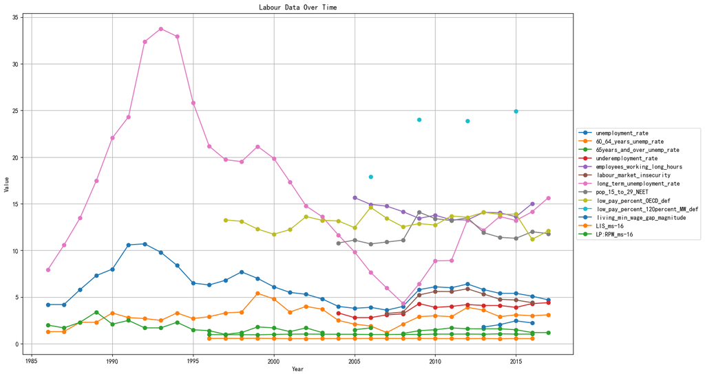

```python
# Labour
# Create a new figure and set the size, and save it in the fig variable
fig = plt.figure(figsize=(16, 10))

# Create a copy and set the 'year' column as index
tmp1 = labour.copy()

# Draw a line chart and specify it to be drawn on the graph represented by fig
tmp1.plot(kind='line', marker='o', ax=fig.gca())
plt.xlabel('Year')
plt.ylabel('Value')
plt.title('Labour Data Over Time')
plt.grid(True)
plt.legend(loc='center left', bbox_to_anchor=(1, 0.5))
plt.show()
```

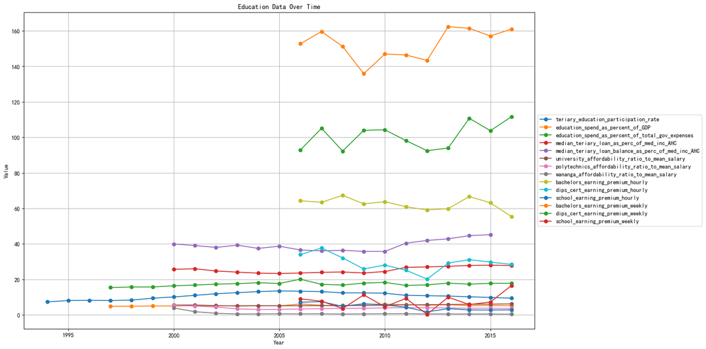

```python
# Education
fig = plt.figure(figsize=(16, 10))

tmp1 = education.copy()

tmp1.plot(kind='line', marker='o', ax=fig.gca())
plt.xlabel('Year')
plt.ylabel('Value')
plt.title('Education Data Over Time')
plt.grid(True)
plt.legend(loc='center left', bbox_to_anchor=(1, 0.5))
plt.show()
```

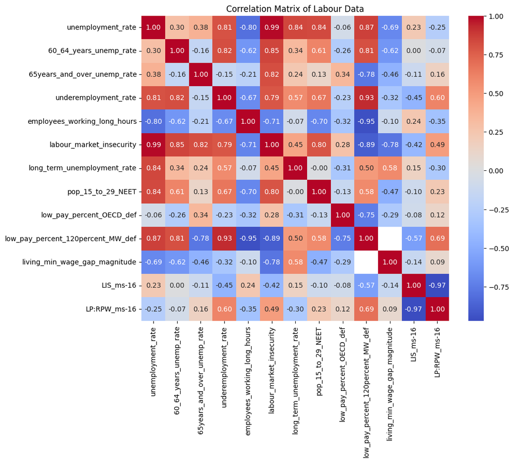

```python
plt.rcParams['font.family'] = 'DejaVu Sans'

correlation_matrix1 = labour.corr()

# Draw Labour heatmap
plt.figure(figsize=(10, 8))
sns.heatmap(correlation_matrix1, annot=True, cmap='coolwarm', fmt=".2f")
plt.title('Correlation Matrix of Labour Data')
plt.show()
```

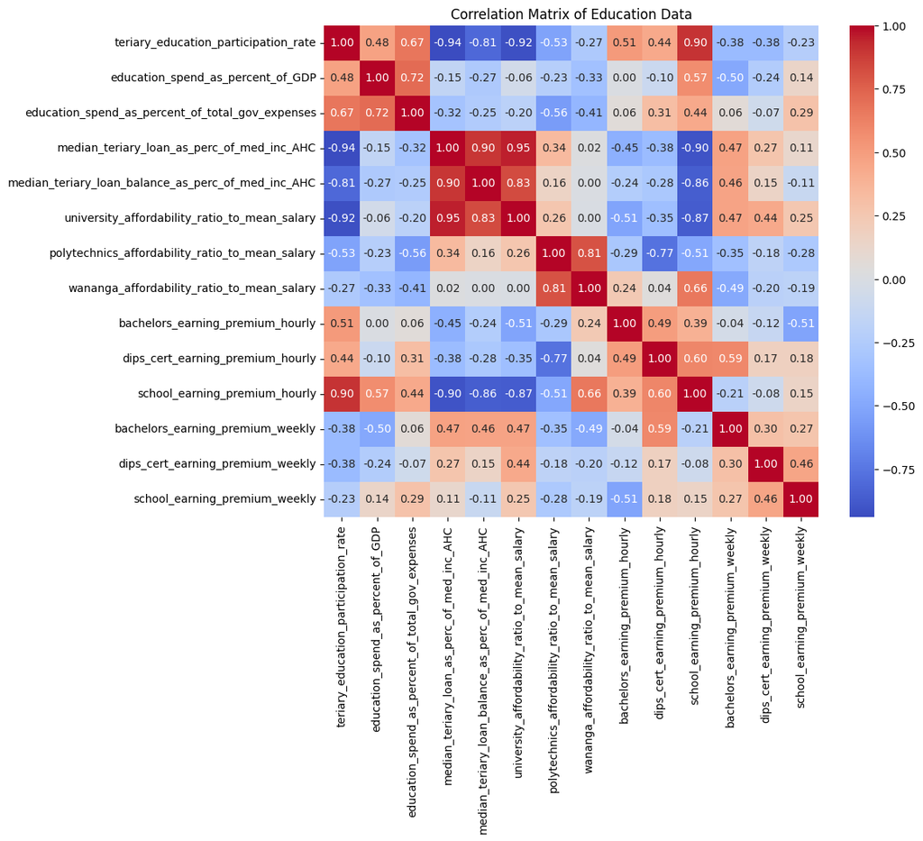

```python
correlation_matrix2 = education.corr()

# Draw Education heatmap
plt.figure(figsize=(10, 8))
sns.heatmap(correlation_matrix2, annot=True, cmap='coolwarm', fmt=".2f")
plt.title('Correlation Matrix of Education Data')
plt.show()
```

# Analysis

[Correlation analysis about labour heatmap]

1.The correlation coefficient between [unemployment_rate] and [labor_market_insecurity] is 0.99, which means that the higher the unemployment rate, the higher the insecurity coefficient of the labor market and the more volatile the market.

2.The correlation coefficient between [underemployment_rate] and [low_pay_percent_120percent_MW_def] is 0.93.Such a strong positive correlation may reflect a phenomenon: when "low_pay_percent_120percent_MW_def" increases, it means that relatively low-paying jobs occupy a larger proportion of the job market. As this ratio increases, it may cause the "underemployment_rate" to rise, because relatively low-wage jobs may not provide enough income to live on, thus increasing the risk of underemployment.

3.The correlation coefficient between [LIS_ms-16] and [LP:RPW_ms-16] is -0.97.This correlation coefficient value of -0.97 indicates a very strong negative relationship between labor productivity and real product wage rates. Specifically, when labor productivity increases, real product wage rates tend to fall, and vice versa. In other words, an increase in productivity may mean that workers' share of wages relative to total output declines, or that workers receive less compensation.Such a strong negative correlation may be due to the fact that productivity gains are often associated with technological progress, automation, or structural changes in the labor market, which may lead to reduced demand for labor or suppressed wage levels.

[Correlation analysis about education heatmap]

1.The correlation coefficient between [teriary_education_participation_rate] and [median_teriary_loan_as_perc_of_med_inc_AHC] is -0.94,Such a strong negative correlation may be due to the following two reasons:  
①The relationship between education costs and loan burdens: Lower participation rates in higher education may mean that more people are choosing not to pursue higher education, possibly because the cost of education is too high. The increase in higher education loans as a share of income may be because those who choose to pursue higher education need more loans to pay for tuition and living expenses;  
②The relationship between economic pressure and education choices: The increase in the proportion of higher education loans to income may lead more people to abandon higher education and choose to enter the job market to reduce the financial burden. As a result, higher education participation rates are likely to decrease.  
Overall, this correlation coefficient result implies that there is a close relationship between higher education participation rate and loan burden, and high loan burden may affect people's choice of higher education.

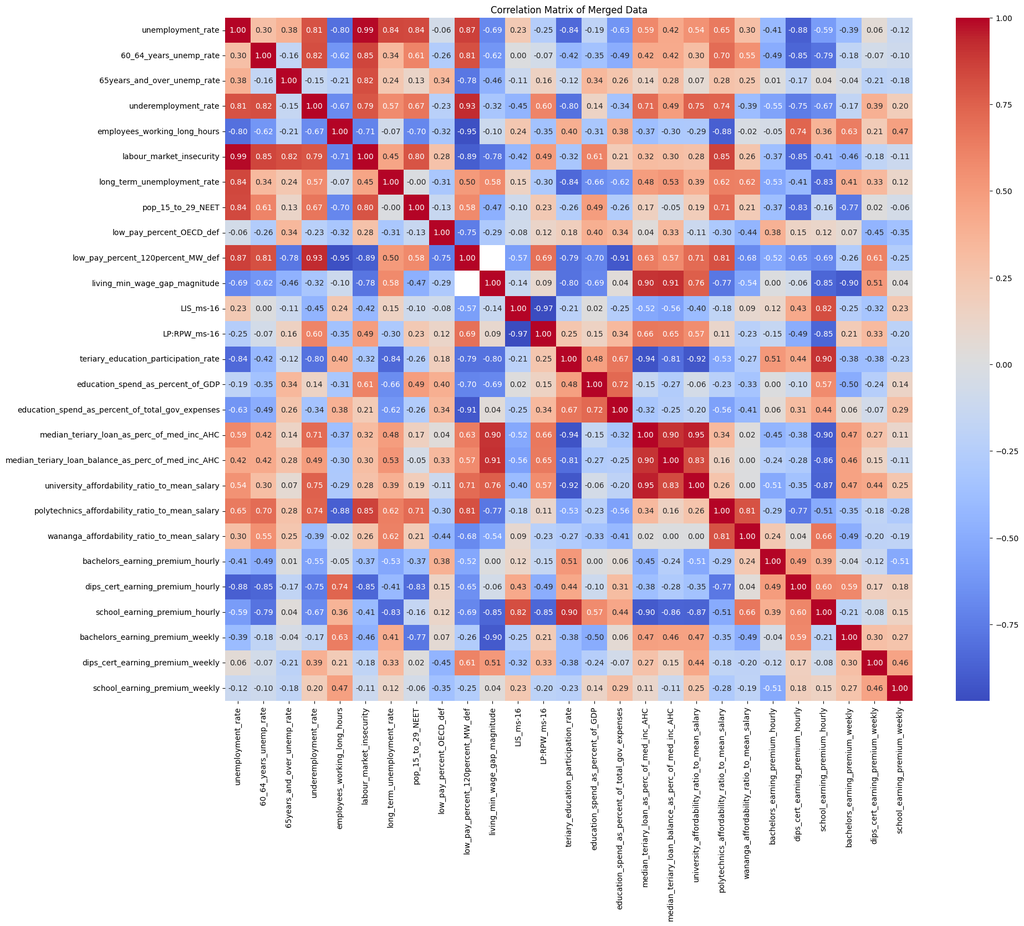

```python
# In order to understand the correlation between the variables of labor and education, merge the two and continue the correlation analysis.
merged_data = pd.concat([labour, education], axis=1)
correlation_matrix = merged_data.corr()

plt.figure(figsize=(20, 16))
sns.heatmap(correlation_matrix, annot=True, cmap='coolwarm', fmt=".2f")
plt.title('Correlation Matrix of Merged Data')
plt.show()
```

[Correlation analysis between labour and education]